# Assignment 3

Eva He, Sarah Xi, Zhijing Zhao

11/13/2019

## Part Ⅰ

```r
customer_orig <- read_csv("https://s3.amazonaws.com/notredame.analytics.data/mallcustomers.csv")
str(customer_orig)
```

```
## Classes 'spec_tbl_df', 'tbl_df', 'tbl' and 'data.frame': 200 obs. of  5 variables:
##  $ CustomerID   : num  1 2 3 4 5 6 7 8 9 10 ...
##  $ Gender       : chr  "Male" NA "Female" "Female" ...
##  $ Age          : num  19 21 20 23 31 22 35 23 64 30 ...
##  $ Income       : chr  "15,000 USD" "15,000 USD" "16,000 USD" "16,000 USD" ...
##  $ SpendingScore: num  39 81 6 77 40 76 6 94 3 72 ...
##  - attr(*, "spec")=
##   .. cols(
##   ..   CustomerID = col_double(),
##   ..   Gender = col_character(),
##   ..   Age = col_double(),
##   ..   Income = col_character(),
##   ..   SpendingScore = col_double()
##   .. )
```

## PART II

### **Subsection 1:**

```r
# change the data type for Gender into factor
customer_orig$Gender = as.factor(customer_orig$Gender)

# use mice function to imput missing values
imputed_customer <- mice(customer_orig, m=1, maxit=5, meth='logreg', seed=1234)
# replace the missing values from original dataset with imputed values
complete_customer <- mice::complete(imputed_customer)

complete_customer
```

```
##     CustomerID Gender Age      Income SpendingScore
## 1            1   Male  19  15,000 USD            39
## 2            2 Female  21  15,000 USD            81
## 3            3 Female  20  16,000 USD             6
## 4            4 Female  23  16,000 USD            77
## 5            5 Female  31  17,000 USD            40
## 6            6 Female  22  17,000 USD            76
## 7            7 Female  35  18,000 USD             6
## 8            8 Female  23  18,000 USD            94
## 9            9   Male  64  19,000 USD             3
## 10          10 Female  30  19,000 USD            72
## 11          11   Male  67  19,000 USD            14
## 12          12 Female  35  19,000 USD            99
## 13          13 Female  58  20,000 USD            15
## 14          14 Female  24  20,000 USD            77
```

[output cut: 186 more lines]

```r
str(complete_customer)
```

```
## 'data.frame':    200 obs. of  5 variables:
##  $ CustomerID   : num  1 2 3 4 5 6 7 8 9 10 ...
##  $ Gender       : Factor w/ 2 levels "Female","Male": 2 1 1 1 1 1 1 1 2 1 ...
##  $ Age          : num  19 21 20 23 31 22 35 23 64 30 ...
##  $ Income       : chr  "15,000 USD" "15,000 USD" "16,000 USD" "16,000 USD" ...
##  $ SpendingScore: num  39 81 6 77 40 76 6 94 3 72 ...
```

### **Subsection 2:**

```r
# use str_replace_all to remove both "USD" and ","
# and convert the data type from character to numeric
complete_customer$Income = str_replace_all(complete_customer$Income, "[USD,]", "")
complete_customer$Income = as.numeric(complete_customer$Income)

complete_customer
```

```
##     CustomerID Gender Age Income SpendingScore
## 1            1   Male  19  15000            39
## 2            2 Female  21  15000            81
## 3            3 Female  20  16000             6
## 4            4 Female  23  16000            77
## 5            5 Female  31  17000            40
## 6            6 Female  22  17000            76
## 7            7 Female  35  18000             6
## 8            8 Female  23  18000            94
## 9            9   Male  64  19000             3
## 10          10 Female  30  19000            72
## 11          11   Male  67  19000            14
## 12          12 Female  35  19000            99
## 13          13 Female  58  20000            15
## 14          14 Female  24  20000            77
```

[output cut: 186 more lines]

```r
str(complete_customer)
```

```
## 'data.frame':    200 obs. of  5 variables:
##  $ CustomerID   : num  1 2 3 4 5 6 7 8 9 10 ...
##  $ Gender       : Factor w/ 2 levels "Female","Male": 2 1 1 1 1 1 1 1 2 1 ...
##  $ Age          : num  19 21 20 23 31 22 35 23 64 30 ...
##  $ Income       : num  15000 15000 16000 16000 17000 17000 18000 18000 19000 19000 ...
##  $ SpendingScore: num  39 81 6 77 40 76 6 94 3 72 ...
```

```r
summary(complete_customer)
```

```
##    CustomerID        Gender         Age            Income
##  Min.   :  1.00   Female:111   Min.   :18.00   Min.   : 15000
##  1st Qu.: 50.75   Male  : 89   1st Qu.:28.75   1st Qu.: 41500
##  Median :100.50                Median :36.00   Median : 61500
##  Mean   :100.50                Mean   :38.85   Mean   : 60560
##  3rd Qu.:150.25                3rd Qu.:49.00   3rd Qu.: 78000
##  Max.   :200.00                Max.   :70.00   Max.   :137000
##  SpendingScore
##  Min.   : 1.00
##  1st Qu.:34.75
##  Median :50.00
##  Mean   :50.20
##  3rd Qu.:73.00
##  Max.   :99.00
```

## PART III

### **Subsection 1:**

```r
# when conducting the cluster analysis, we want to exclude customerID, gender and age
customer_seg <- complete_customer %>%
  select(-CustomerID, -Gender, -Age)

# since the min and max of income are significantly different, and income and spendingscore are not presented on the same scale
# we normalize the data with the z-score normalization
customer_seg_z <- scale(customer_seg)
summary(customer_seg_z)
```

```
##      Income         SpendingScore
##  Min.   :-1.73465   Min.   :-1.905240
##  1st Qu.:-0.72569   1st Qu.:-0.598292
##  Median : 0.03579   Median :-0.007745
##  Mean   : 0.00000   Mean   : 0.000000
##  3rd Qu.: 0.66401   3rd Qu.: 0.882916
##  Max.   : 2.91037   Max.   : 1.889750
```

```r
# We set the value for k to 3 to create 3 clusters
# and choose to use 25 different initial configuration
# We also want to set seed so that every time we run the code, the clustering result will be the same
set.seed(1234)
customer_cluster <- kmeans(customer_seg_z, centers = 3, nstart = 25)

customer_cluster$size
```

```
## [1] 123  39  38
```

### **Subsection 2:**

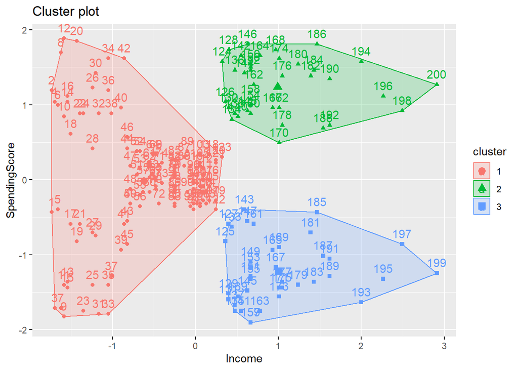

```r
# visualize the clustering result
fviz_cluster(customer_cluster, data = customer_seg_z)
```

### **Subsection 3:**

```r
# to determine the right number of clusters, we use elbow method
wcss <- vector()

# we calculate the WCSS to try to determine the right number of clusters we need
n = 20
set.seed(1234)
for(k in 1:n) {
  wcss[k] <- sum(kmeans(customer_seg_z, k)$withinss)
}

wcss
```

```
##  [1] 398.00000 272.68128 156.91549 108.37671  65.24057  54.78206  44.64043
##  [8]  40.45087  48.02401  38.71335  31.85579  27.65295  23.45477  22.81869
## [15]  22.44992  18.36966  16.35522  16.14122  15.68263  16.78943
```

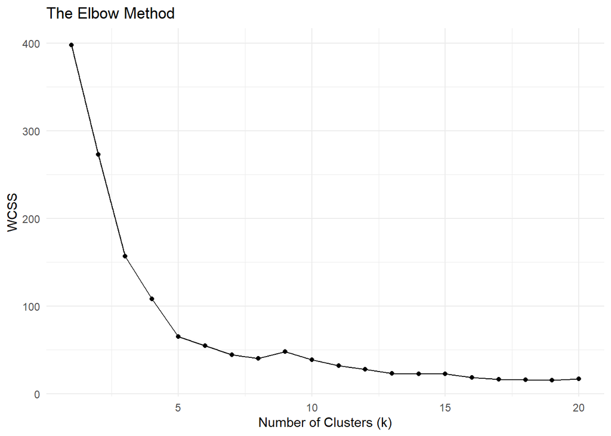

```r
# visualize the elbow method
tibble(value = wcss) %>%
  ggplot(mapping = aes(x = seq(1,length(wcss)), y=value)) +
  geom_point()+
  geom_line() +
  labs(title = "The Elbow Method", y = "WCSS", x = "Number of Clusters (k)" ) +
  theme_minimal()
```

```r
# based on the Elbow Method, we decided to choose 3, 4, 5 and 7 to experiment on the visualization parts
```

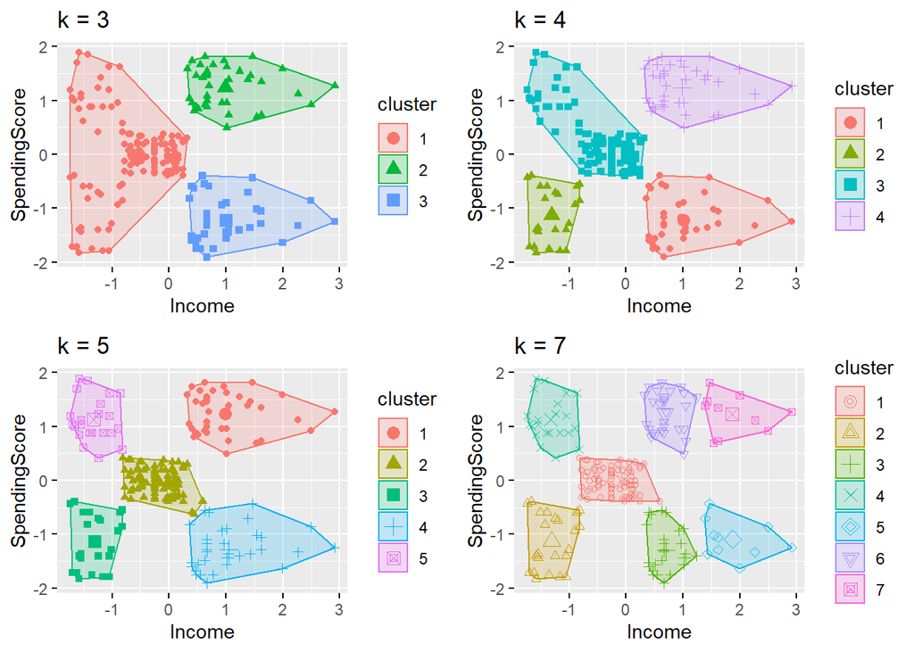

```r
# since we selected 3, 4, 5, 7 as our potential final number of clusters, we perform clustering for each approach
set.seed(1234)
customer_cluster_4 <- kmeans(customer_seg_z, centers = 4, nstart = 25)
customer_cluster_5 <- kmeans(customer_seg_z, centers = 5, nstart = 25)
customer_cluster_7 <- kmeans(customer_seg_z, centers = 7, nstart = 25)

# visuzlize four cluster approaches at the same time
p1 <- fviz_cluster(customer_cluster, data = customer_seg_z, labelsize = 0) + ggtitle("k = 3")
p2 <- fviz_cluster(customer_cluster_4, data = customer_seg_z, labelsize = 0) + ggtitle("k = 4")
p3 <- fviz_cluster(customer_cluster_5, data = customer_seg_z, labelsize = 0) + ggtitle("k = 5")
p4 <- fviz_cluster(customer_cluster_7, data = customer_seg_z, labelsize = 0) + ggtitle("k = 7")

grid.arrange(p1, p2, p3, p4, nrow = 2)
```

```r
# examine the cluster size for each cluster approach
customer_cluster_4$size
```

```
## [1]  38  23 100  39
```

```r
customer_cluster_5$size
```

```
## [1] 39 81 23 35 22
```

```r
customer_cluster_7$size
```

```
## [1] 79 23 27 22 10 29 10
```

Conlusion:

We believe that the best number of clusters would be 5 based on the visualization comparison. As we can see in the graph, when cluster number equals to 5, each cluster boundry is clear, clusters include complete datasets and there are little overlapping.

Additionally, the size of cluster 1 is too big when we only have 3 clusters and some data points are far away from each other on the graph.

When cluster number is 5, we can see that cluster 2 contains relatively more data than other clusters but based on the graph, these data points are really close to each other and it is unnecessary to plit them into more detailed clusters. Even though that there are some extreme points in cluster 1 and 4, they still belong to a general category and it is unnecessary to specifically pick out these data points. Together with the Elbow Method graph, we believe that 5 is the optimal number for clusters.

### **Subsection 4:**

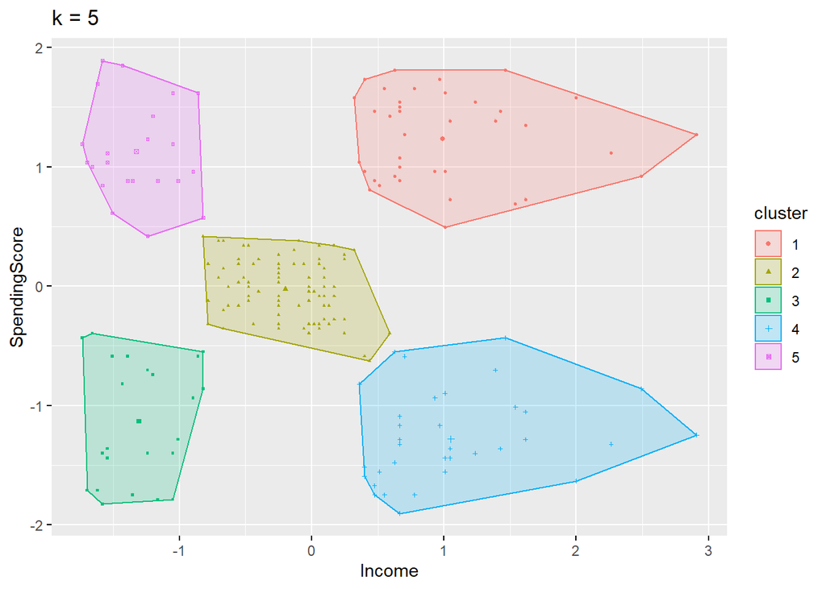

```r
fviz_cluster(customer_cluster_5, data = customer_seg_z, pointsize = 0.5 ,labelsize = 0) +
  ggtitle("k = 5")
```

## PART IV

### **Subsection 1:**

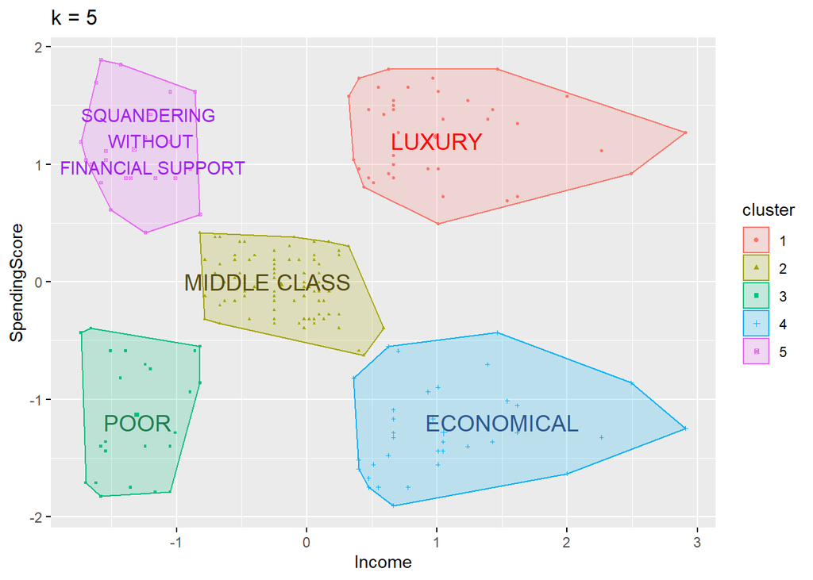

```r
fviz_cluster(customer_cluster_5, data = customer_seg_z, pointsize = 0.5 ,labelsize = 0) +
  ggtitle("k = 5")+
  annotate(geom="text", x=-1.2, y=1.2, label="SQUANDERING \n WITHOUT \n FINANCIAL SUPPORT",color="purple",size = 4)+
  annotate(geom="text", x=1, y=1.2, label="LUXURY",color="red",size = 5)+
  annotate(geom="text", x=-0.3, y=0, label="MIDDLE CLASS",color='#564e12',size = 5)+
  annotate(geom="text", x=-1.3, y=-1.2, label="POOR",color="#1e8052",size = 5)+
  annotate(geom="text", x=1.5, y=-1.2, label="ECONOMICAL",color="#2b5891",size = 5)
```

cluster 1: high income and high spending score: LUXURY

cluster 2: medium income and medium spending score: MIDDLE CLASS

cluster 3: low income and low spending score: POOR

cluster 4: high income and low spending score: ECONOMICAL

cluster 5: low income and high spending score: SQUANDERING WITHOUT FINANCIAL SUPPORT

### **subsection 2:**

```r
complete_customer$cluster = customer_cluster_5$cluster

# to calculate the average age for each cluster
age_cluster <- complete_customer %>%
  group_by(cluster) %>%
  summarize(Age = mean(Age))

# to calculate the average age for the entire customer group
# since we will add two data frame together, we add an additional column with the name of "cluster" and value of "overall"
age_overall <- complete_customer %>%
  summarize(Age = mean(Age)) %>%
  mutate(cluster = "Overall") %>%
  select(cluster, Age)

# use rbind to combine two data frames
age_comparison = rbind(data.frame(age_cluster), data.frame(age_overall))
age_comparison
```

```
##   cluster      Age
## 1       1 32.69231
## 2       2 42.71605
## 3       3 45.21739
## 4       4 41.11429
## 5       5 25.27273
## 6 Overall 38.85000
```

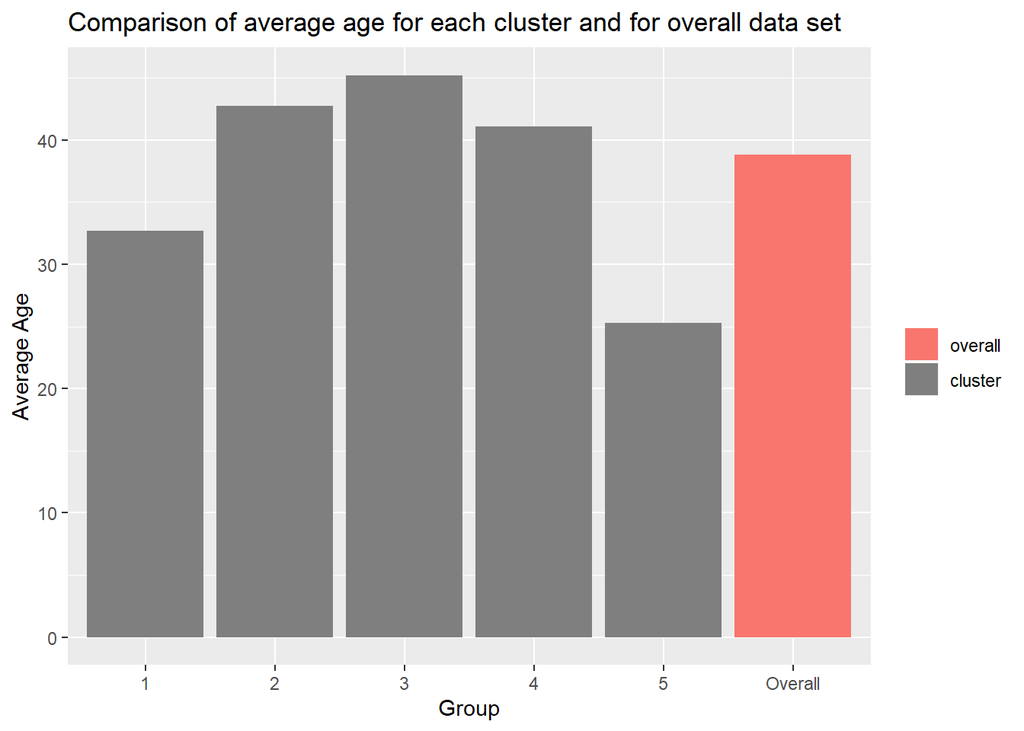

```r
# the color code for the graph
area_color <- c(NA, NA, NA, NA, NA, "withcolor")

# plot the graph
age_comparison %>%
  ggplot(aes(x = cluster, y = Age, fill = area_color)) +
  geom_col() +
  theme(legend.title = element_blank()) +
  ylab("Average Age") +
  xlab("Group") +
  scale_fill_discrete(labels = c("overall", "cluster")) +
  ggtitle("Comparison of average age for each cluster and for overall data set")
```

```r
# to calcuate gender distribution for each cluster
gender_cluster <- complete_customer %>%
  group_by(cluster, Gender) %>%
  summarize(n = n()) %>%
  select(cluster, Gender, n)

# to calculate the gender distribution for the overall customer group
gender_overall <- complete_customer %>%
  group_by(Gender) %>%
  summarize(n = n()) %>%
  mutate(cluster = "Overall") %>%
  select(cluster, Gender, n)

# use rbind to combine two data frames
gender = rbind(data.frame(gender_cluster), data.frame(gender_overall))
gender
```

```
##    cluster Gender   n
## 1        1 Female  20
## 2        1   Male  19
## 3        2 Female  46
## 4        2   Male  35
## 5        3 Female  15
## 6        3   Male   8
## 7        4 Female  13
## 8        4   Male  22
## 9        5 Female  17
## 10       5   Male   5
## 11 Overall Female 111
## 12 Overall   Male  89
```

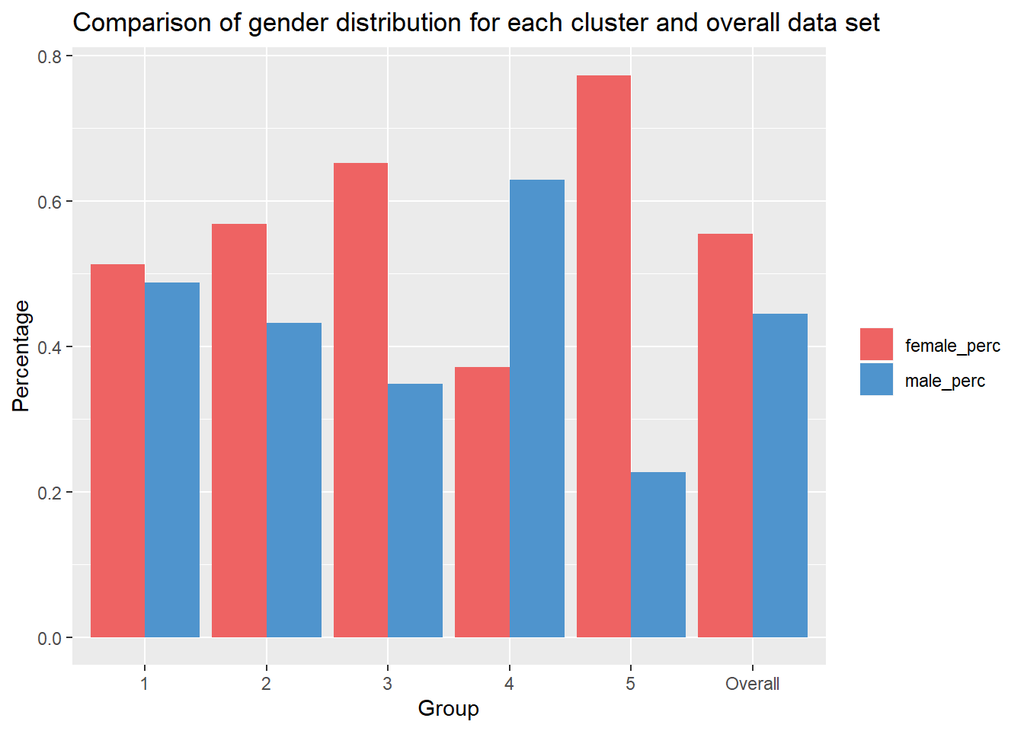

```r
# use spread to spread the value in the Gender column so that all the information for gender for each cluster are shown in its own row
# we then calculate the female and male percentage
# it is easier to draw graphs when values are in the same variable column, so we gather the "female_perc" and "male_perc" into one column called "Percentage"


# we do not want "Female" and "Male" in our final graph, so we remove these columns when making the bar chart
# we use position = "dodge" to make side by side bars, with "Gender_perc" as the rule to assign different colors
gender_comparison <- gender %>%
  spread(Gender, n) %>%
  mutate(female_perc = Female / (Female + Male), male_perc = Male / (Male + Female)) %>%
  gather(Gender_perc, Percentage, -Female, -Male, -cluster) %>%
  select(cluster, Gender_perc, Percentage) %>%
  arrange(cluster, desc(Gender_perc)) %>%
  ggplot(aes(x = cluster, y = Percentage, fill = as.factor(Gender_perc))) +
  geom_col(position = "dodge") +
  scale_fill_manual(values=c("indianred2", "steelblue3")) +
  theme(legend.title = element_blank()) +
  xlab("Group") +
  ggtitle("Comparison of gender distribution for each cluster and overall data set")

gender_comparison
```

### **Subsection 3:**

**Cluster 1:**

These customers have high income and are willing to spend a lot. The average age for this group is 32 and there is an nearly even distribution of gender. For this group, they focus on pursing the fashion and stating social status, such as bags, clothes, watches, cufflinks, ties, and they also want to get updated about the latest fashion in time. We want to provide some exclusive offer of newly released merchandise in the retail cards, however, since these people will buy these luxuries no matter what, the offer will not include any discounts, but will provide purchase priority. Additionally, we can also provide some special services, such as personal sales guide, premium lounge, sending brochures/letters about newly releaased merchandises, special birthday gifts to make these customers purchase more products becuase of our premium services.

**Cluster 2:**

These customers have medium income and typically spend medium amount in boutique stores. The average age for this group is 42 and the number of female is slightly higher than the number of male. Customers in this group typically are married, have kids and tend to focus on the family. The coupons that are offered by the retail card can include discounts for high-end boutique stores whose price range from medium to high and for a wide variety of products including those for kids. However, these coupons cannot be applied on the newly released merchandise. The end goal is to encourange them to increase their spending in the shopping mall.

**Cluster 3:**

These customers have low income and typically do not spend much in boutique stores. The average age for this group is 45 and the number of female is almost twice the number of male. They have the potential to become people in cluster 5, which is low income but high spending score, so we want to send encourage them to spend more in these boutique stores. The retail cards will offer them big sales on out-of-season merchandise, such as clothes and shoes. The cards can also provide some free gifts when their spending amount reaches certain thresholds.

**Cluster 4:**

These customers have high income but spend low in boutique stores. The average age for them is 41 and the number of male is almost twice the number of females. These people are conservative in spending money. We need to further investigate on these people’s purchase preferences to find out the merchandises that they are interested in and are sold in these boutique stores. After the investigation, we can provide discounts and promotions that are similar to cluster 2, but can choose to focus more on the boutique stores that cater to these customers’ special needs.

**Cluster 5:**

These customers have low income but spend a lot in boutique stores. The average age for them is 25 and the number of female is almost triple the number of male. These people might be want to purchase stylish fashion items. So the retail cards specially made for these people can offer discounts for clothes and shoes in medium-level boutique stores and collaboration brands. We might also allow the retail card holder in cluster 5 to purchase goods or services on credit.

Overall, for both old and new customers, we can show all 5 retail card options to them and they can choose freely based on their backgrounds. However, there are spending restrictions on each retail card level so that only they reached certain spending amount, they can apply for another type of retail card.